# Project presentation: FN-sambandet

ISSSV1337

## Contents

1. Case description
2. Methods and Limitations
3. Findings
4. Social Media
5. Policy recommendations

[figure not shown]

## 1. Case description

## 2. Methods

- **Stortingscrape** A R-package developed by Martin Søyland, Use to retrieve date from stortingets open data source
- Text analysis and topic modeling
- Key word searches, word counts
- **I. Questions**
- **II. Decisions**
- **III. Hearings**
- **IV. Budget**
- **V. Social Media impact**

## 3. Stortingscrape

```r
sessions_storting <- get_parlsessions()

sessions_storting <- sessions_storting %>%
  filter(id %in% c("2011-2012", "2012-2013", "2013-2014",
                   "2014-2015", "2015-2016", "2016-2017",
                   "2017-2018", "2018-2019", "2019-2020",
                   "2020-2021", "2021-2022"))
a<-list()
b<-list()
c<-list()

for(x in unique(sessions_storting$id)){
  a[[x]] <- get_session_questions(sessionid = x, q_type = "interpellasjoner",
                                  status = NA, good_manners = 0)
  b[[x]] <- get_session_questions(sessionid = x, q_type = "sporretimesporsmal",
                                  status = NA, good_manners = 0)
  c[[x]] <- get_session_questions(sessionid = x, q_type = "skriftligesporsmal",
                                  status = NA, good_manners = 0)}
```

## Operationalization

- Choice of keywords

[figure not shown]

## I. Questions

**Question analysis** - as you may or may not know, mps ask questions - these questions provide a possiblity to hold the government accountable - Or to promote ones own policy agenda

**A quick look at the data** - We have in our particular period, 27 792 questions asked. - With such a large amount of questions we should expect exciting results.

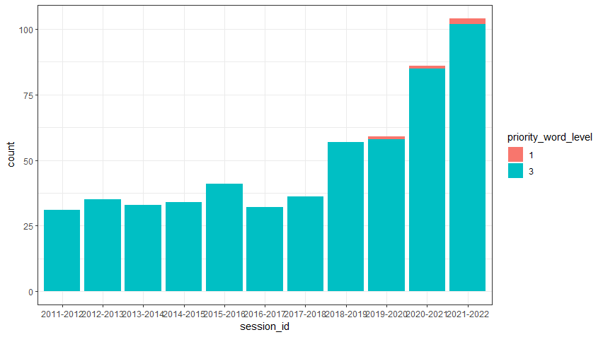

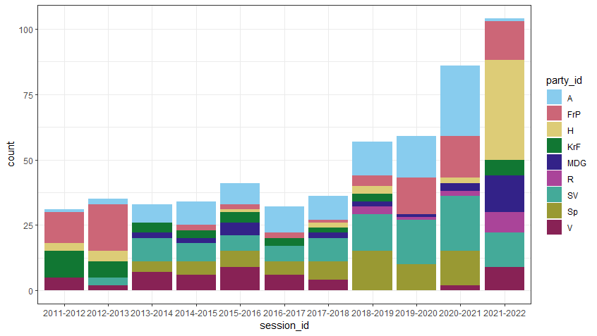

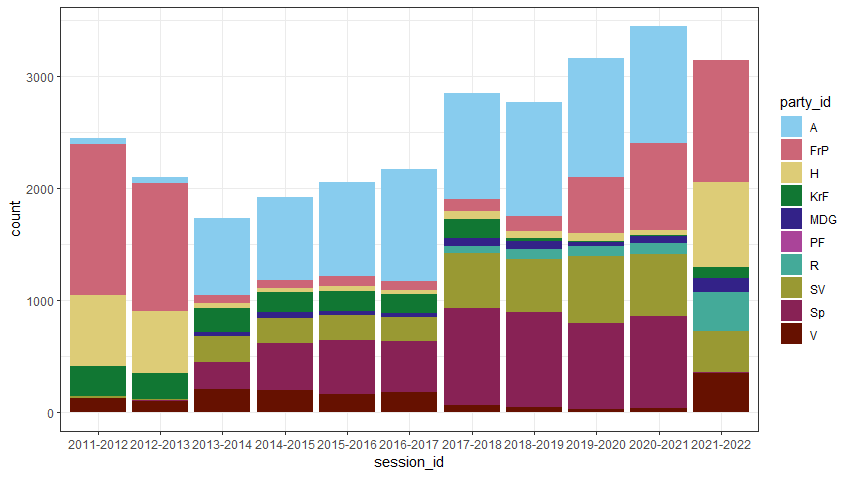

## What do we see here?

- People are suddenly talking a lot about UN related orgs and stuff.
- I think we all have a clue about it being somewhat related to Ukraine.
- Unsurprisingly it seems people are using the UN organisations to talk about the big current event.

## What more can we do here?

- The size of our corpus lends itself to being applied to Structural Topic Modeling (STM)
- An stm is a form of unsupervised machine learning, based on grouping documents after shared characteristics.
- We can use this to create an overview over what kind of topics the questions that mention UNA or sustainable development are about.
- We tokenize, stem and create a dfm over the entire documents.

## What are the results of the topic assignment to our central documents?

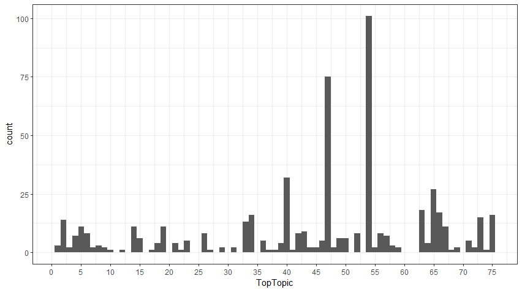

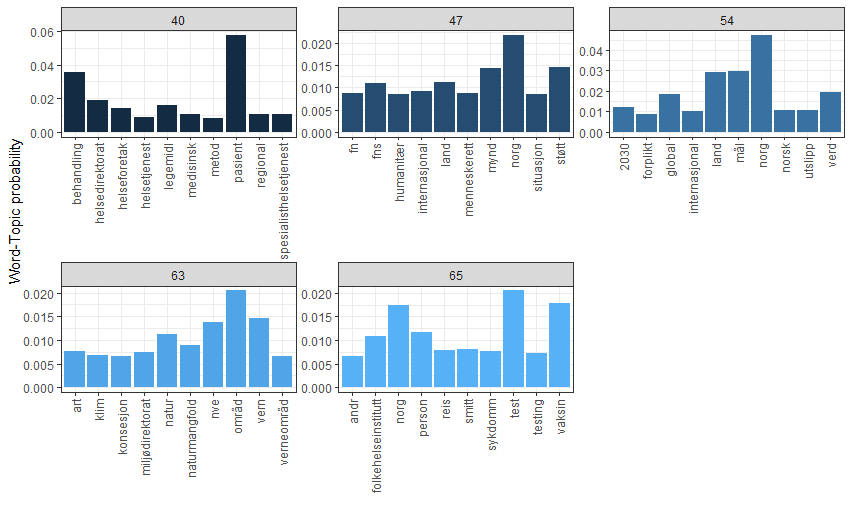

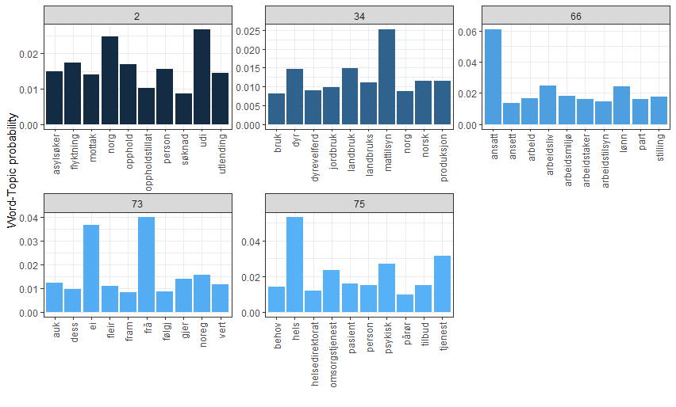

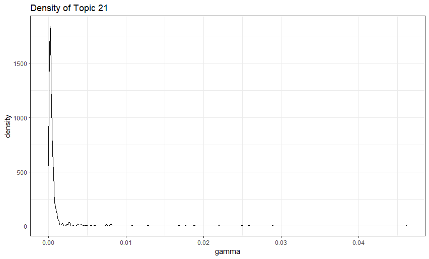

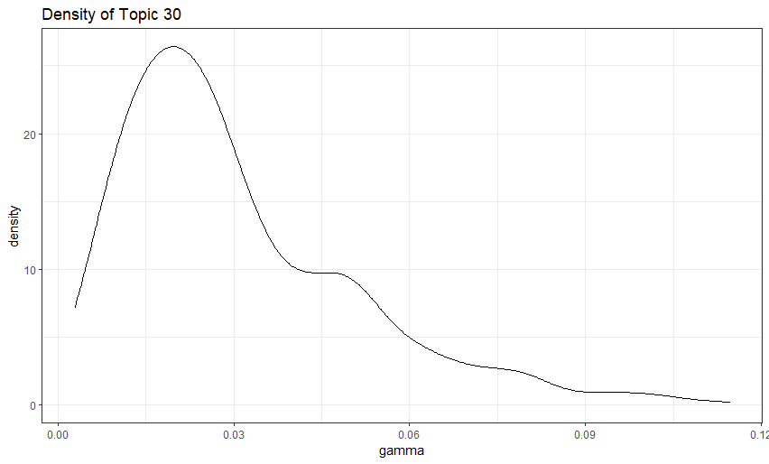

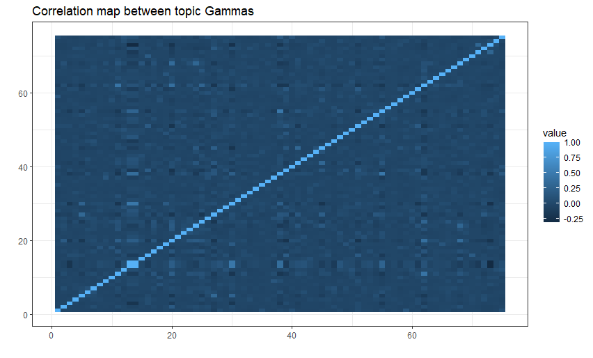

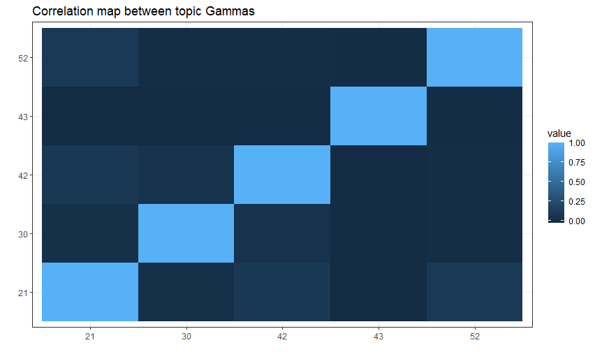

## Findings

- Sustainability and education is not readily shared with each other
- It is mentioned more in regards to university level education
- Low focus on "høyskoler" and on elementary schools.
- The crossections of gammas on sustainability and education, work as a measure of UBU knowledge.
- In the future this code, or modified versions of it, can be run on future sessions, to isolate the degree to which these topics intersect in the future.

## II.Decisions

```r
decisionslista <- do.call("rbind", a)

sum(str_detect(decisionslista$decision_text, "FN-sambandet"))
# 0 mentions of the spesific string FN-sambandet

sum(str_detect(decisionslista$decision_text, "4,7"))
# 19 mentions of 4,7

sum(str_detect(decisionslista$decision_text, "utdanning for bærekraftig utvikling"))
# 0 mentions of education for sustainable development

sum(str_detect(decisionslista$decision_text, "utdanning"))
# 291 mentions of education

sum(str_detect(decisionslista$decision_text, "bærekraftig"))
# 82 mentions of sustainable
```

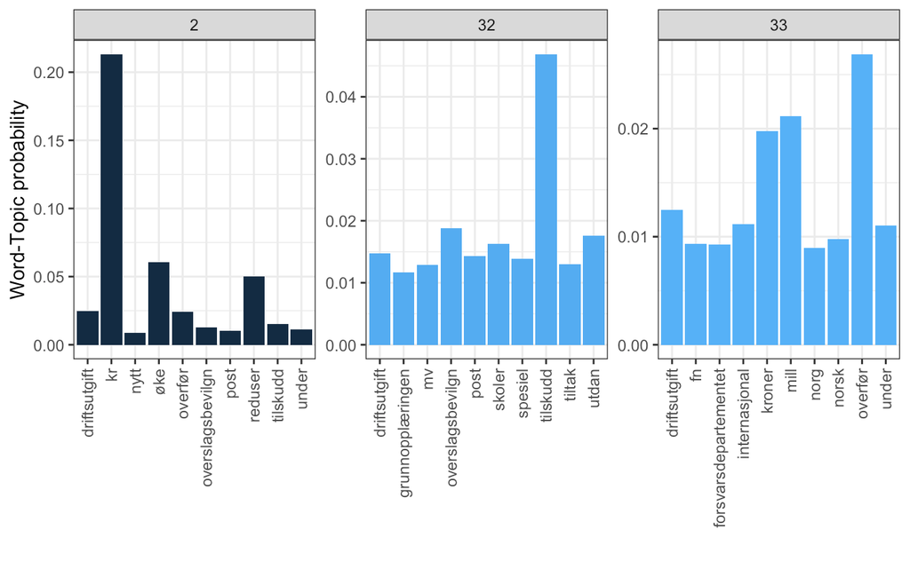

```r
toppingtopicswords_top1 <- decisiontopics_group %>%
  filter(topic %in% c(2,32,33))



toppingtopicswords_top1 %>%
  ggplot(aes(term, beta, fill = topic)) +
  geom_bar(stat = "identity") +
  facet_wrap( ~ topic,
              ncol = 3,
              scales = "free") +
  labs(x = "", y = "Word-Topic probability") +
  theme_bw() +
  theme(legend.position = "none",
        axis.text.x = element_text(angle = 90, vjust = 0.5, hjust = 1))
```

## III. Hearings

- Prio 1, Prio 2, Prio 3.
- Only one mention of FN-Sambandet in hearings
- No mentions related to SDG 4.7 and terms related to sustainable education
- 9 mentions of UN organization since 2019 (causal relationships)

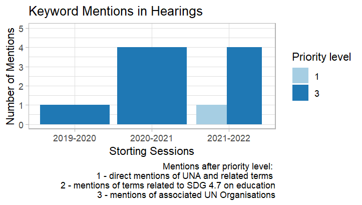

## Challenges hearings

- Few observations
- Data availability before 2019-2020 parliament session

## Budget Analysis

- The adventure into the decisions gave some specific results
- We found that there were mostly budgets.
- This meant we could find a way to automate the retrieval of those budgets
- or did it…?
- Lessons learned

## Adventures in REGEX

```r
grab_text <- function(text, target, before, after){
  min <- which(unlist(map(str_split(text, "\\s"), ~grepl(target, .x))))-before
  max <- which(unlist(map(str_split(text, "\\s"), ~grepl(target, .x))))+after

  paste(str_split(text, "\\s")[[1]][min:max], collapse = " ")
}

undpbudget <- list()
undpbudgetn <- list()
```

```r
for (x in 1:length(UN_decisions$cleanedtext_l)) {
  if(str_detect(UN_decisions$cleanedtext_l[x], "undp")){
    undpbudget[[x]] <- grab_text(text = UN_decisions$cleanedtext_l[x], target = "undp", before = 1, after  = 14)
    if(str_detect(undpbudget[[x]], "reduseres")){
      tmpred <- grab_text(text = undpbudget[[x]], target = "til", before = 0, after = 4)
      tmp1 <- str_extract(tmpred, "[:digit:]{1,3}\\s[:digit:]{1,3}\\s[:digit:]{1,3}")
      undpbudgetn[[x]] <- (as.numeric(str_remove_all(tmp1, " ")))
    }else{

      if(str_detect(undpbudget[[x]], "auka")){
        tmpinc <- grab_text(text = UN_decisions$cleanedtext_l[x], target = "undp", before = 1, after = 20)
        tmpinc2 <- grab_text(text = tmpinc, target = "til", before = 0, after = 5)
        tmpinc3 <- str_extract(tmpinc2, "[:digit:]{1,3}\\s[:digit:]{1,3}\\s[:digit:]{1,3}")

        undpbudgetn[[x]] <- (as.numeric(str_remove_all(tmpinc3, " ")))

      }else{

        tmp1 <- str_extract(undpbudget[[x]], "([:digit:]{1,3}\\s?)[:digit:]{1,3}\\s[:digit:]{1,3}\\s[:digit:]{3}")

        undpbudgetn[[x]] <- (as.numeric(str_remove_all(tmp1, " ")))
      }}
  }else{next}
}
```

- All of this to retrieve 15 lines of information
- And that is how you turn a 15 minute task, into a 3-day project
- **automation**

**Regardless of how it was retrieved, here are the results**

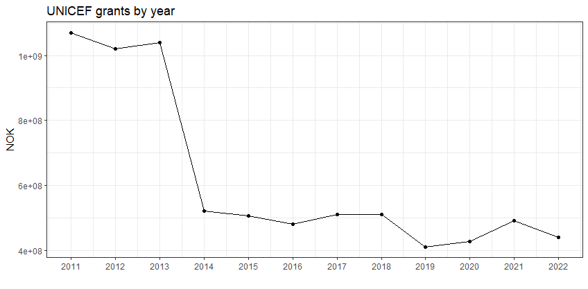

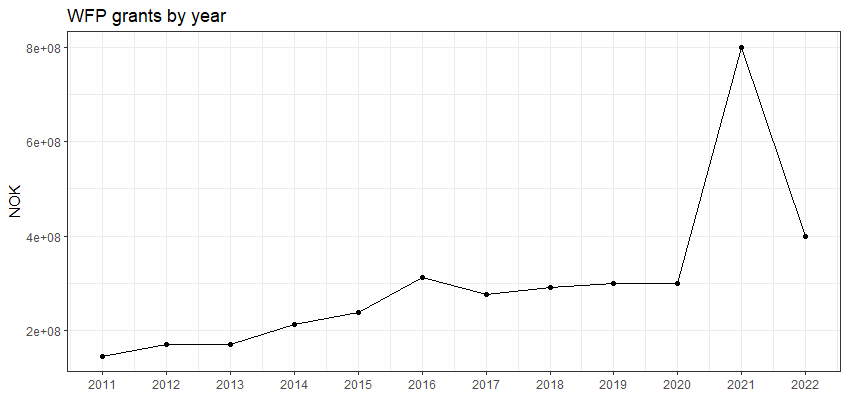

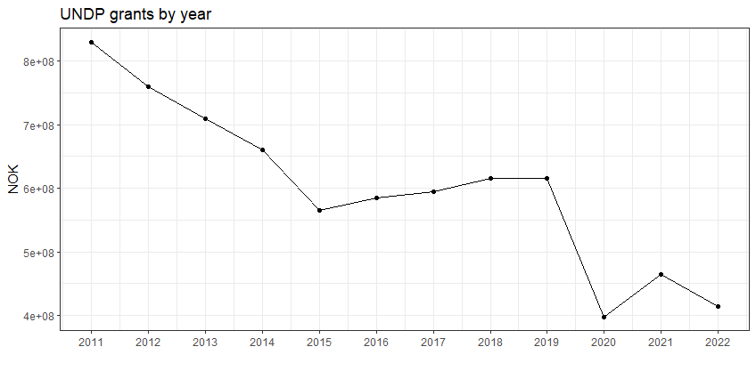

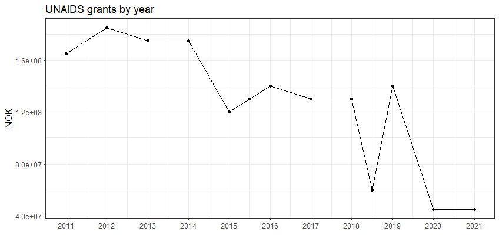

## 4. Social media

- Due to lack of administrative access we have not been able to scrape FN-sambandets Facebook and instagram profiles

## How to extract data from Facebook and Instagram

```r
FNS <- getUserMedia(username = "fnsambandet",
                    token = TokenInsta)

comments <- getComments(FNS$id[Cgv3mNjqhvk],
            token = TokenInsta,
            verbose = TRUE)
```

## Twitter I

```r
store api keys (replace with your own - these are fake examples)
api_key <- "000"
api_secret_key <- "ABC"


access_token <- "123abc"
access_token_secret <- "dddd"

# authenticate
token <- create_token(
  app = "thename",
  consumer_key = api_key,
  consumer_secret = api_secret_key,
  access_token = access_token,
  access_secret = access_token_secret)
```

## Twitter II

```r
Using search_tweets to find all tweets related to the string FNsambandet
We see that there are 9 tweets related to the string FNsambandet

#Search tweets related to FNsambandet
twts_fnsambandet <- search_tweets("FNsambandet", n = 1000)


# Create a table of the different tweets
sc_twts <- data.frame(twts_fnsambandet$full_text)
sc_twts


Here I try to search for tweets that use the hashtag #FNsambandet,
however it returns a dataset of 0 obs, which means there are no one who uses the hashtag on Twitter

twts_hashtag <- search_tweets("#FNsambandet",
                           n = 2000)



# Searching for the strings "utdanning for bærekratig utvikling" and "ubu", which is part of
FN's Sustainable Development Goal 4, Quality Education, an important part of FN-Sambandet's work.

#Search tweets related to FN goal 4,7
tweets_ubu <- search_tweets("utdanning for bærekraftig utvikling", n = 10000)


#Search tweets related to sdg4,7
tweets_sdg <- search_tweets("sdg4,7", n = 1000, lang= "en")

sc_sdg <- table(tweets_sdg$full_text)
sc_sdg
```

## Twitter III

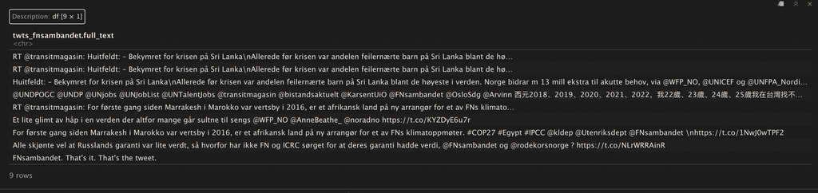

## 5. Policy recommendations

- Increase visibility on social media and in parliament
- Create a coherent communication strategy and use keywords consistently
- **Issue-linking** priority 1-> priority 2-> priority 3
- Self reporting enables analysis of performance -> tailor further startegy and improve targeting

## Choice of keywords

[figure not shown]

## Thanks for your attention and the amazing summer